# forum_analysis

Ben Hicks

14/10/2019

# Understanding the results

In the tabular results for each forum network below, there are a few concepts worth outlining.

## Overall structure and definitions

**Nodes** : The nodes (or vertices, or actors, or egos…) in the network are the people involved in the forum. The total number (recorded as *nodes* below) is just the number of students enrolled plus any academics that participated in the forum. Students in the course that did not post in the forum are included.

**Edges** : The edges in the network represent ‘interactions’ between students on the forum. So if Student A replies to a forum post of Student B, then this is represented by connecting those two students with an edge (line). These edges are directed; Student A replying to a post of Student B connects $A \rightarrow B$. Note that an edge in this context is a collection of forum posts (and the associated text data) between two people.

**Density** : How ‘full’ the network is, calculated as the ratio of edges in the graph to the total number of possible edges.

**Average Path Length** : A *path* in this context is a series of forum-connected students, and this is the average length of this paths. It is sometimes called the *degree of separation* or the *characteristic path length*, and along with centralisation is a key measure in graph-level summary statistics[^1].

**Edge betweenness** : A measure of the ‘strength’ of an edge, by finding approximately how many shortest paths pass through that particular edge.

## Triads

Studying each subset of possible 3-node subgraphs in the network has been shown to be effective in analysing affiliation networks[^2][^3].

### Mutual-Asymmetric-Null Triadic Classes

The Mutual-Asymmetric-Null encoding system classifies triad connections in a *directed graph*. The three numbers represent, in order, the number of (M)utual edges, the number of (A)symmetric edges, and the number of (N)ull or no edges between nodes. The possible connections (and their names) are outlined below:

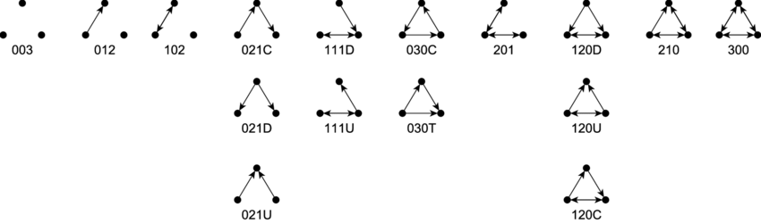

### Triad Census

The *Triad Census* classifies all 3-node subsets according to the Mutual-Asymmetric-Null class above, and is compared to the expected number of those triads for a random graph of the same number of nodes and density.

## Expected values

All these measures are useful, but hard to know what to compare them to. One way around this is to compare them to random graphs with similar properties[^4][^5]. So for each analysed network 500 random graphs were generated using the same number of nodes and density. The random graphs are generated using the *Erdos-Renyi* method[^6], and then the results averaged to generate an approximate expected value of each given metric.

# Comparisons

## Subject A, 2017

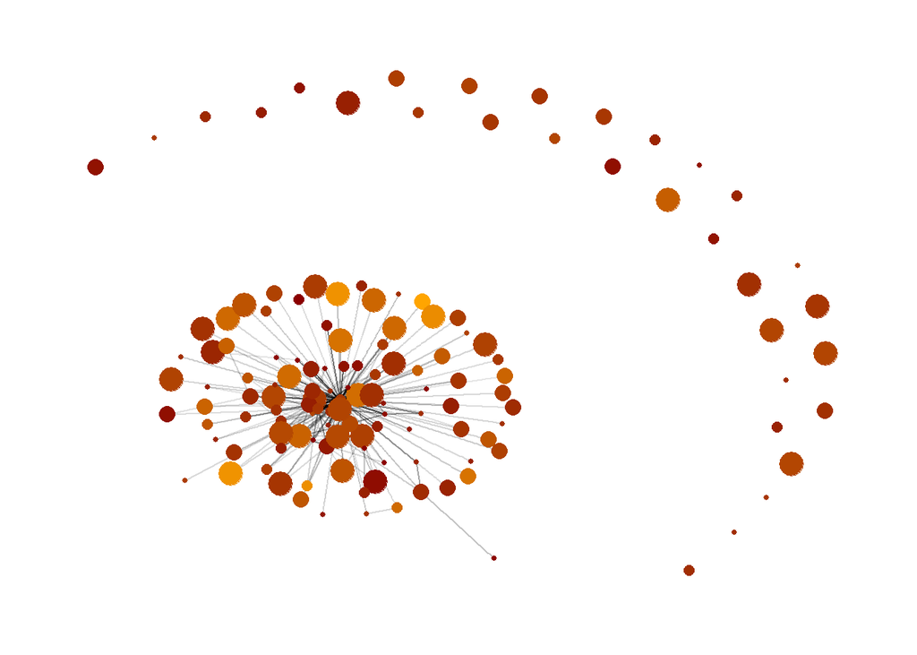

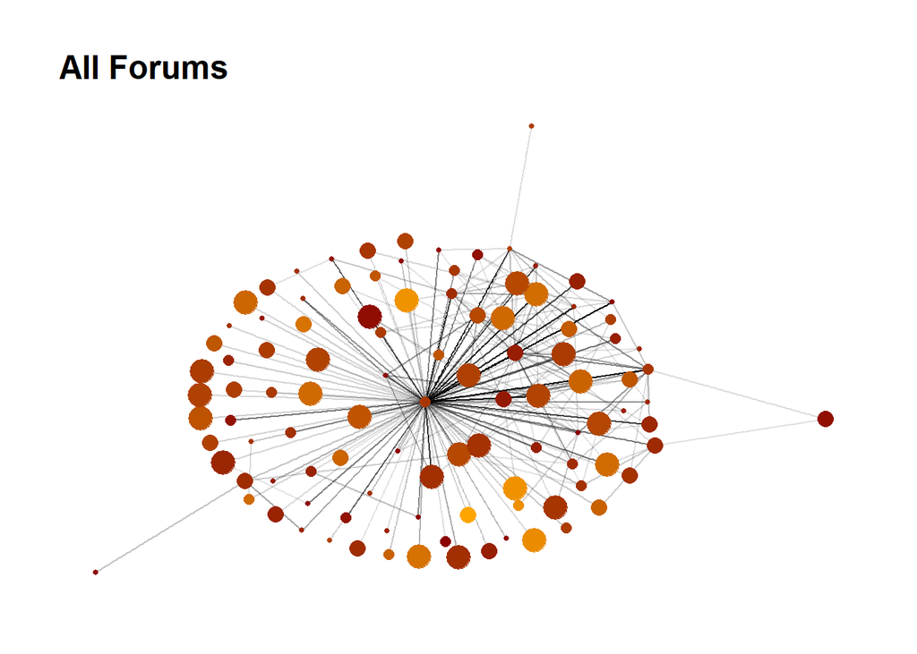

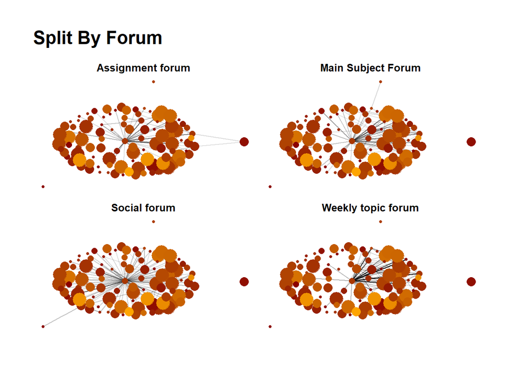

| Nodes | Desnsity | Reciprocity | Expected.Reciprocity | Transitivity | Expected.Transitivity | Centralization | Expected.Centralization |
| --- | --- | --- | --- | --- | --- | --- | --- |
| 137 | 0.026 | 0.543 | 0.027 | 0.083 | 0.051 | 0.349 | 0.059 |

| MAN_class | Triads | expected |
| --- | --- | --- |
| 003 | 395,143 | 357,576 |
| 012 | 12,208 | 57,618 |
| 102 | 6,012 | 788 |
| 021D | 216 | 773 |
| 021U | 1,228 | 774 |
| 021C | 263 | 1,549 |
| 111D | 2,447 | 42 |
| 111U | 389 | 42 |
| 030T | 8 | 42 |
| 030C | 1 | 14 |
| 201 | 1,143 | 1 |
| 120D | 9 | 1 |
| 120U | 16 | 1 |
| 120C | 27 | 1 |
| 210 | 76 | 0 |
| 300 | 34 | 0 |

Same as above, but with the isolated points removed:

| Nodes | Desnsity | Reciprocity | Expected.Reciprocity | Transitivity | Expected.Transitivity | Centralization | Expected.Centralization |
| --- | --- | --- | --- | --- | --- | --- | --- |
| 105 | 0.045 | 0.543 | 0.045 | 0.083 | 0.086 | 0.598 | 0.047 |

| MAN_class | Triads | expected |
| --- | --- | --- |
| 003 | 170,519 | 142,589 |
| 012 | 7,856 | 39,900 |
| 102 | 3,228 | 951 |
| 021D | 216 | 928 |
| 021U | 1,228 | 929 |
| 021C | 263 | 1,861 |
| 111D | 2,447 | 88 |
| 111U | 389 | 89 |
| 030T | 8 | 86 |
| 030C | 1 | 29 |
| 201 | 1,143 | 2 |
| 120D | 9 | 2 |
| 120U | 16 | 2 |
| 120C | 27 | 4 |
| 210 | 76 | 0 |
| 300 | 34 | 0 |

## Subject A, 2018

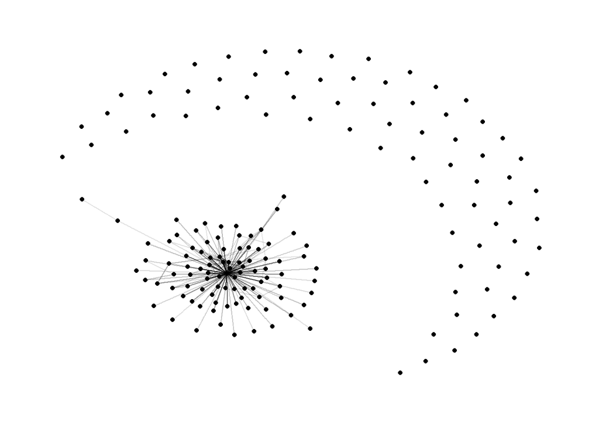

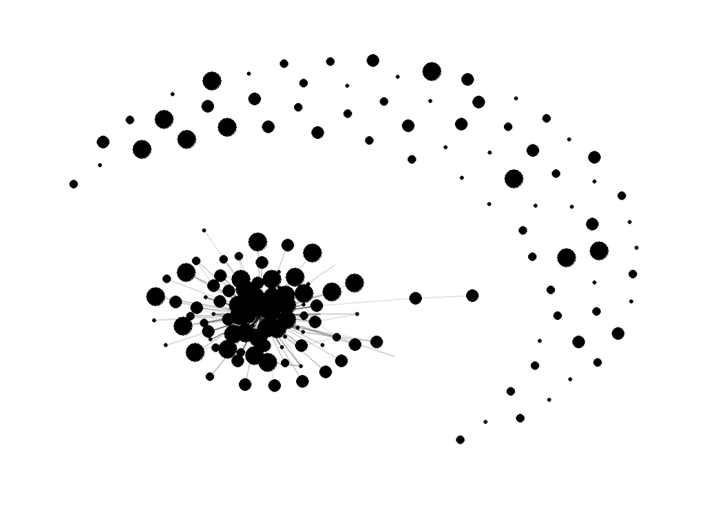

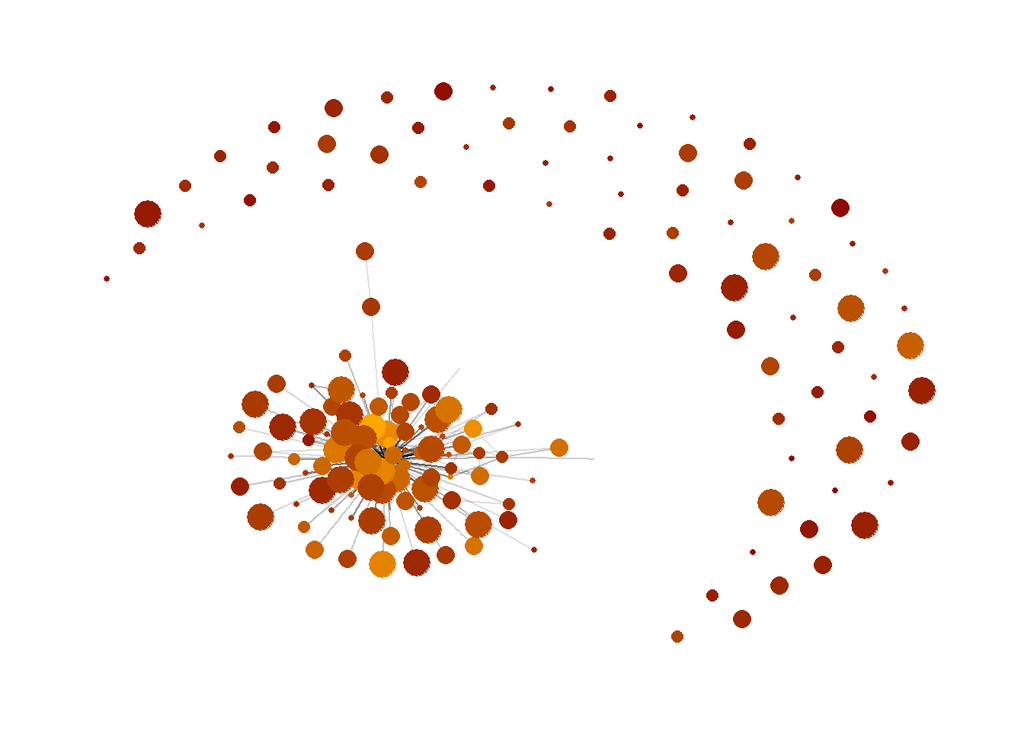

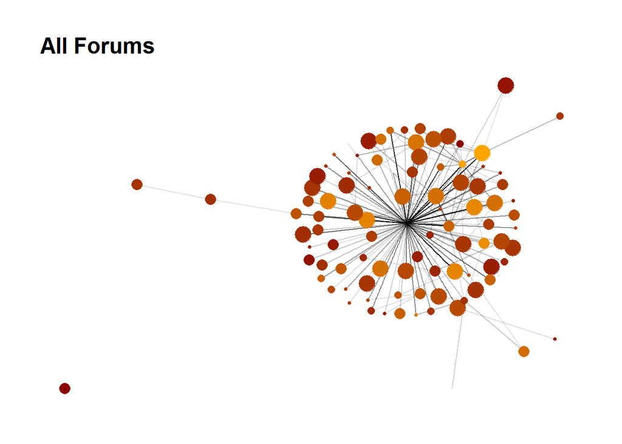

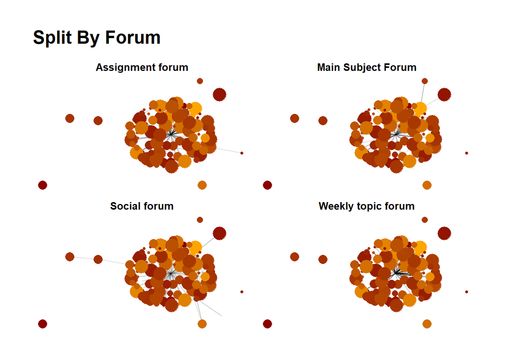

| Nodes | Desnsity | Reciprocity | Expected.Reciprocity | Transitivity | Expected.Transitivity | Centralization | Expected.Centralization |
| --- | --- | --- | --- | --- | --- | --- | --- |
| 166 | 0.016 | 0.634 | 0.016 | 0.061 | 0.031 | 0.239 | 0.082 |

| MAN_class | Triads | expected |
| --- | --- | --- |
| 003 | 726,172 | 681,280 |
| 012 | 10,370 | 64,756 |
| 102 | 8,122 | 515 |
| 021D | 65 | 513 |
| 021U | 275 | 515 |
| 021C | 198 | 1,026 |
| 111D | 1,357 | 16 |
| 111U | 433 | 17 |
| 030T | 3 | 16 |
| 030C | 1 | 5 |
| 201 | 1,584 | 0 |
| 120D | 0 | 0 |
| 120U | 3 | 0 |
| 120C | 14 | 0 |
| 210 | 50 | 0 |
| 300 | 13 | 0 |

Same as above, but with the isolated points removed:

| Nodes | Desnsity | Reciprocity | Expected.Reciprocity | Transitivity | Expected.Transitivity | Centralization | Expected.Centralization |
| --- | --- | --- | --- | --- | --- | --- | --- |
| 95 | 0.048 | 0.634 | 0.048 | 0.061 | 0.093 | 0.739 | 0.052 |

| MAN_class | Triads | expected |
| --- | --- | --- |
| 003 | 127,429 | 103,206 |
| 012 | 4,761 | 31,044 |
| 102 | 2,229 | 780 |
| 021D | 65 | 779 |
| 021U | 275 | 778 |
| 021C | 198 | 1,557 |
| 111D | 1,357 | 78 |
| 111U | 433 | 79 |
| 030T | 3 | 78 |
| 030C | 1 | 26 |
| 201 | 1,584 | 2 |
| 120D | 0 | 2 |
| 120U | 3 | 2 |
| 120C | 14 | 4 |
| 210 | 50 | 0 |
| 300 | 13 | 0 |

## Subject B, 2017

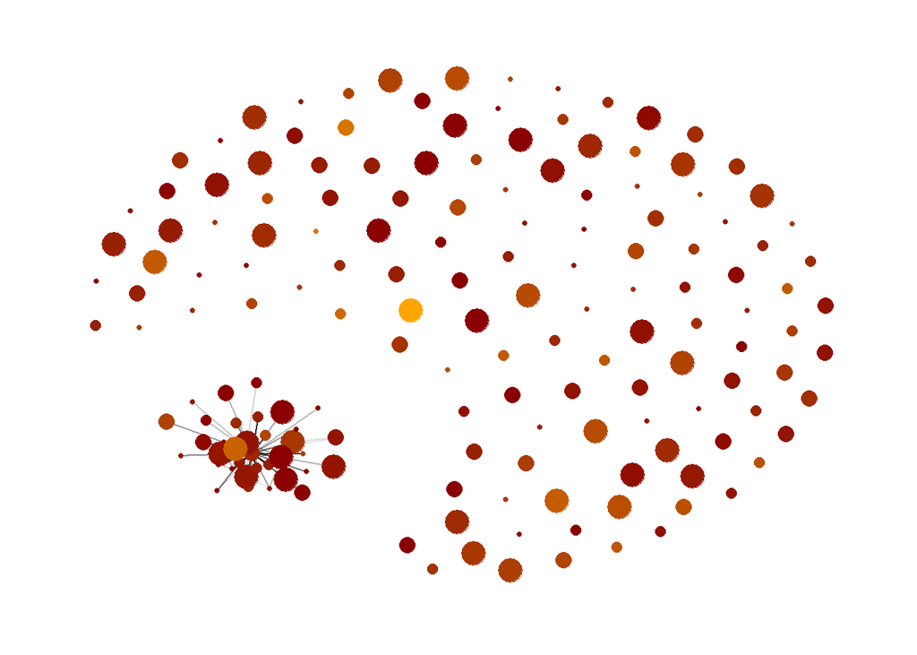

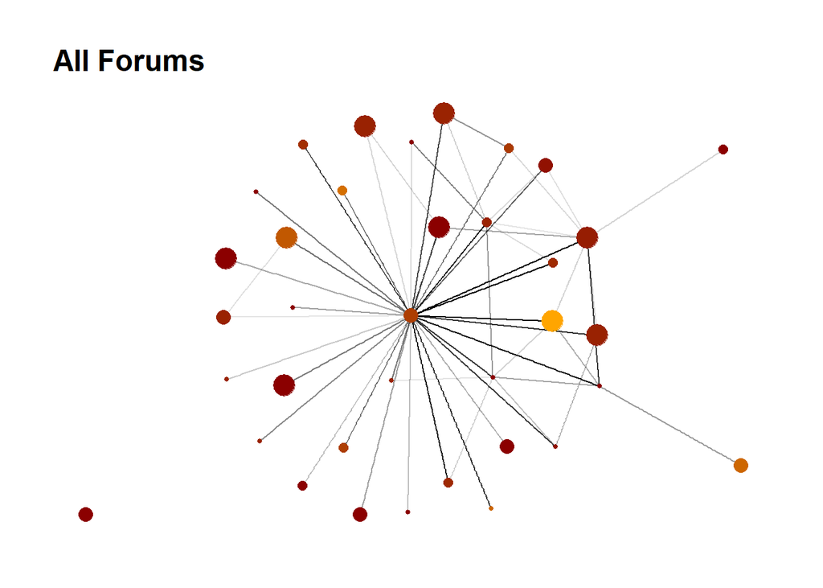

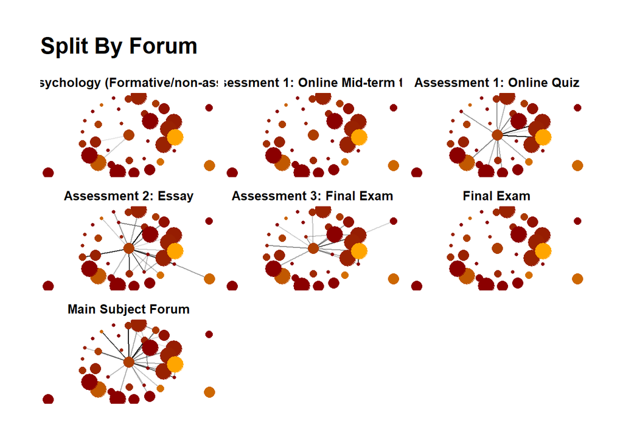

| Nodes | Desnsity | Reciprocity | Expected.Reciprocity | Transitivity | Expected.Transitivity | Centralization | Expected.Centralization |
| --- | --- | --- | --- | --- | --- | --- | --- |
| 167 | 0.007 | 0.766 | 0.006 | 0.126 | 0.013 | 0.034 | 0.031 |

| MAN_class | Triads | expected |
| --- | --- | --- |
| 003 | 753,544 | 732,401 |
| 012 | 3,177 | 29,458 |
| 102 | 5,066 | 95 |
| 021D | 17 | 98 |
| 021U | 6 | 99 |
| 021C | 19 | 198 |
| 111D | 70 | 1 |
| 111U | 118 | 1 |
| 030T | 0 | 1 |
| 030C | 1 | 0 |
| 201 | 312 | 0 |
| 120D | 0 | 0 |
| 120U | 0 | 0 |
| 120C | 3 | 0 |
| 210 | 15 | 0 |
| 300 | 7 | 0 |

Same as above, but with the isolated points removed:

| Nodes | Desnsity | Reciprocity | Expected.Reciprocity | Transitivity | Expected.Transitivity | Centralization | Expected.Centralization |
| --- | --- | --- | --- | --- | --- | --- | --- |
| 36 | 0.147 | 0.766 | 0.143 | 0.126 | 0.269 | 0.777 | 0.067 |

| MAN_class | Triads | expected |
| --- | --- | --- |
| 003 | 5,796 | 2,757 |
| 012 | 426 | 2,848 |
| 102 | 350 | 238 |
| 021D | 17 | 246 |
| 021U | 6 | 245 |
| 021C | 19 | 490 |
| 111D | 70 | 82 |
| 111U | 118 | 82 |
| 030T | 0 | 85 |
| 030C | 1 | 28 |
| 201 | 312 | 7 |
| 120D | 0 | 7 |
| 120U | 0 | 7 |
| 120C | 3 | 14 |
| 210 | 15 | 3 |
| 300 | 7 | 0 |

## Subject B, 2018

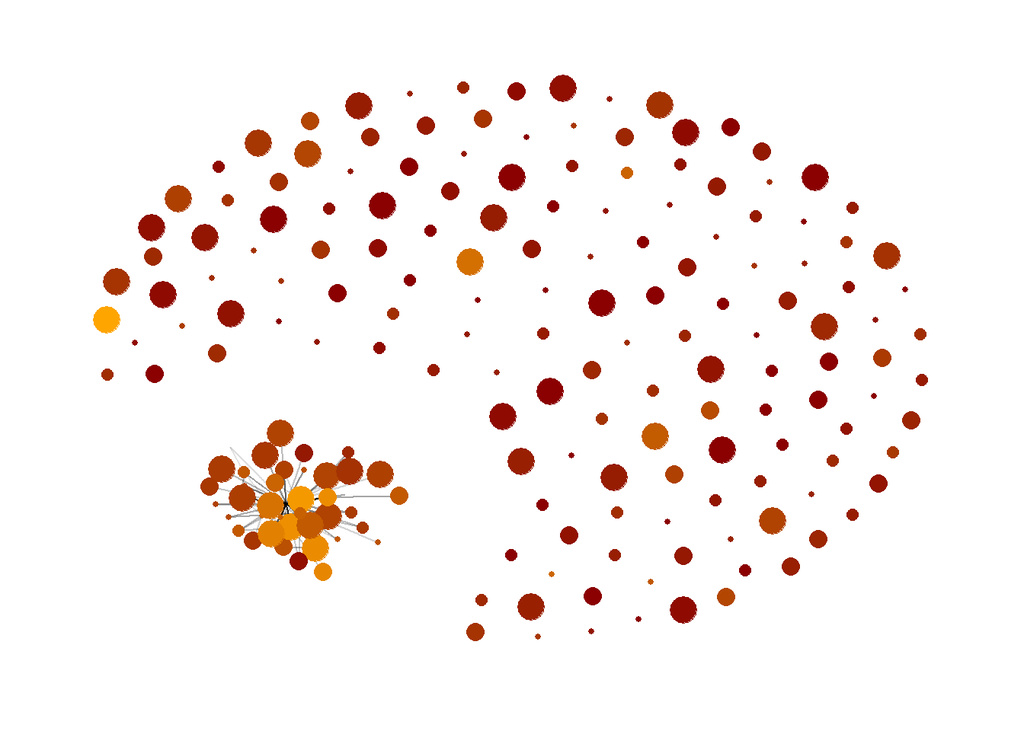

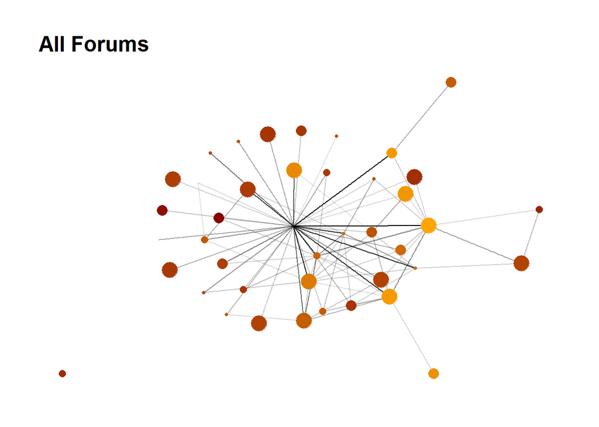

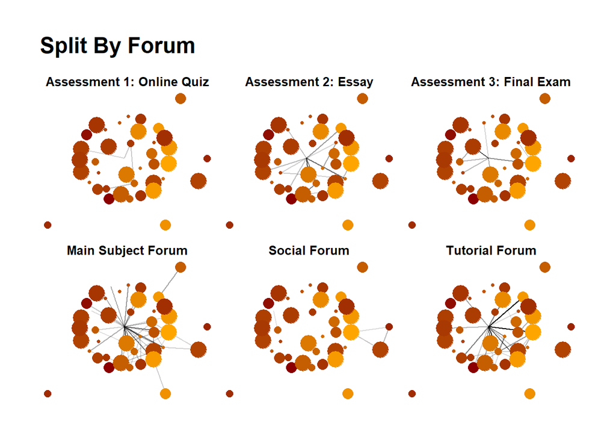

| Nodes | Desnsity | Reciprocity | Expected.Reciprocity | Transitivity | Expected.Transitivity | Centralization | Expected.Centralization |
| --- | --- | --- | --- | --- | --- | --- | --- |
| 190 | 0.006 | 0.558 | 0.006 | 0.175 | 0.011 | 0.032 | 0.025 |

| MAN_class | Triads | expected |
| --- | --- | --- |
| 003 | 1,110,276 | 1,087,101 |
| 012 | 7,780 | 37,530 |
| 102 | 6,291 | 112 |
| 021D | 92 | 108 |
| 021U | 38 | 108 |
| 021C | 101 | 217 |
| 111D | 109 | 1 |
| 111U | 242 | 1 |
| 030T | 3 | 1 |
| 030C | 2 | 0 |
| 201 | 196 | 0 |
| 120D | 3 | 0 |
| 120U | 7 | 0 |
| 120C | 17 | 0 |
| 210 | 19 | 0 |
| 300 | 4 | 0 |

Same as above, but with the isolated points removed:

| Nodes | Desnsity | Reciprocity | Expected.Reciprocity | Transitivity | Expected.Transitivity | Centralization | Expected.Centralization |
| --- | --- | --- | --- | --- | --- | --- | --- |
| 42 | 0.119 | 0.558 | 0.117 | 0.175 | 0.224 | 0.676 | 0.069 |

| MAN_class | Triads | expected |
| --- | --- | --- |
| 003 | 9,008 | 5,338 |
| 012 | 1,120 | 4,365 |
| 102 | 519 | 290 |
| 021D | 92 | 298 |
| 021U | 38 | 297 |
| 021C | 101 | 595 |
| 111D | 109 | 80 |
| 111U | 242 | 79 |
| 030T | 3 | 81 |
| 030C | 2 | 27 |
| 201 | 196 | 5 |
| 120D | 3 | 5 |
| 120U | 7 | 5 |
| 120C | 17 | 11 |
| 210 | 19 | 2 |
| 300 | 4 | 0 |

# Analysis

## Triadic Census Transitions

| MAN class | Sub A 2017 | Sub A 2018 | Sub B 2017 | Sub B 2018 |
| --- | --- | --- | --- | --- |
| 120D | 9 | 0 | 0 | 3 |
| 120U | 16 | 3 | 0 | 7 |
| 120C | 27 | 14 | 3 | 17 |
| 210 | 76 | 50 | 15 | 19 |
| 300 | 34 | 13 | 7 | 4 |

## Homophily

Examining the chance that two nodes are conected based on having similar properties. Need more data for this, only really relevant for the grade quartile data at the moment. Krackhardt’s E-I Index[^7] represents the ratio of internal to external ties:

$$E-I\ Index=\frac{EL - IL}{EL + IL}$$

In the above $EL$ is the number of external links and $IL$ is the number of internal links. Values closer to 1 indicate more heterophily (links between groups are common) where as values closer to -1 indicate more homophily (links within groups are more common).

E-I Index

| group | Sub A 2017 | Sub A 2018 | Sub B 2017 | Sub B 2018 |
| --- | --- | --- | --- | --- |
| grade_quartile | 0.376 | 0.442 | 0.330 | 0.278 |
| cluster_2 | -0.507 | -0.243 | -0.600 | -0.341 |
| cluster_3 | -0.142 | -0.168 | -0.038 | -0.166 |
| cluster_4 | -0.138 | -0.098 | -0.005 | -0.117 |
| cluster_5 | 0.080 | -0.098 | -0.005 | -0.127 |

# References

[^1]: D. Watts & S. Strogatz (1998). *Collective dynamics of ‘small-world’ networks* http://dx.doi.org/10.1038/30918
[^2]: Davis, J.A. and Leinhardt, S. (1972). *The Structure of Positive Interpersonal Relations in Small Groups.* In J. Berger (Ed.), Sociological Theories in Progress, Volume 2, 218-251. Boston: Houghton Mifflin.
[^3]: Brunson (2016). *Triadic analysis of affiliation networks* https://arxiv.org/pdf/1502.07016.pdf
[^4]: D. Watts & S. Strogatz (1998). *Collective dynamics of ‘small-world’ networks* http://dx.doi.org/10.1038/30918
[^5]: Bearman & Hoffman (2017). *Social Network Analysis* https://www.markanthonyhoffman.com/social_network_analysis/index.html
[^6]: Erdos, P. and Renyi, A., (1959). *On random graphs, Publicationes Mathematicae 6*, 290–297.
[^7]: Krackhardt, David, and Robert N. Stern. *Informal Networks and Organizational Crises: An Experimental Simulation.* Social Psychology Quarterly 51, no. 2 (1988): 123-40. http://www.jstor.org/stable/2786835.